# SPEW Output Summary

Synthetic Populations and Ecosystems of the World

[figure not shown]

# DELAWARE

There is/are 3 level(s) of nested ecosystems in Delaware.

There is/are 214 lowest level subregions.

## Data

The raw counts, microdata, and shapefiles are from the US Census.

## Maps

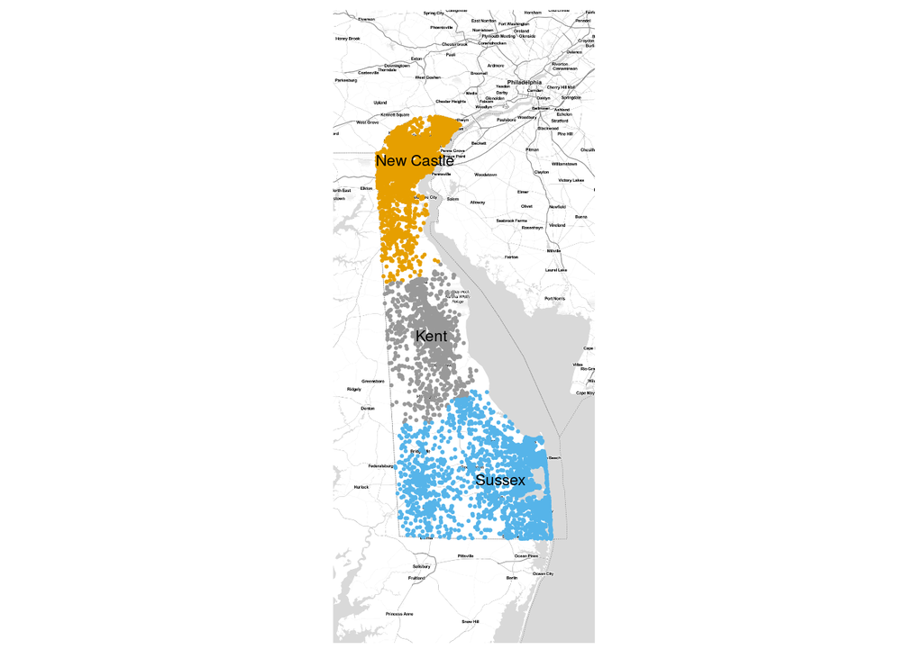

The above map shows a sub-sample of the different sub regions. Each region has a sample of up to 10,000 households.

## Synthetic Households

**Total Synthetic Households:** 202,308

### Households Per Region

Below is a bar chart of the number of households in each region.

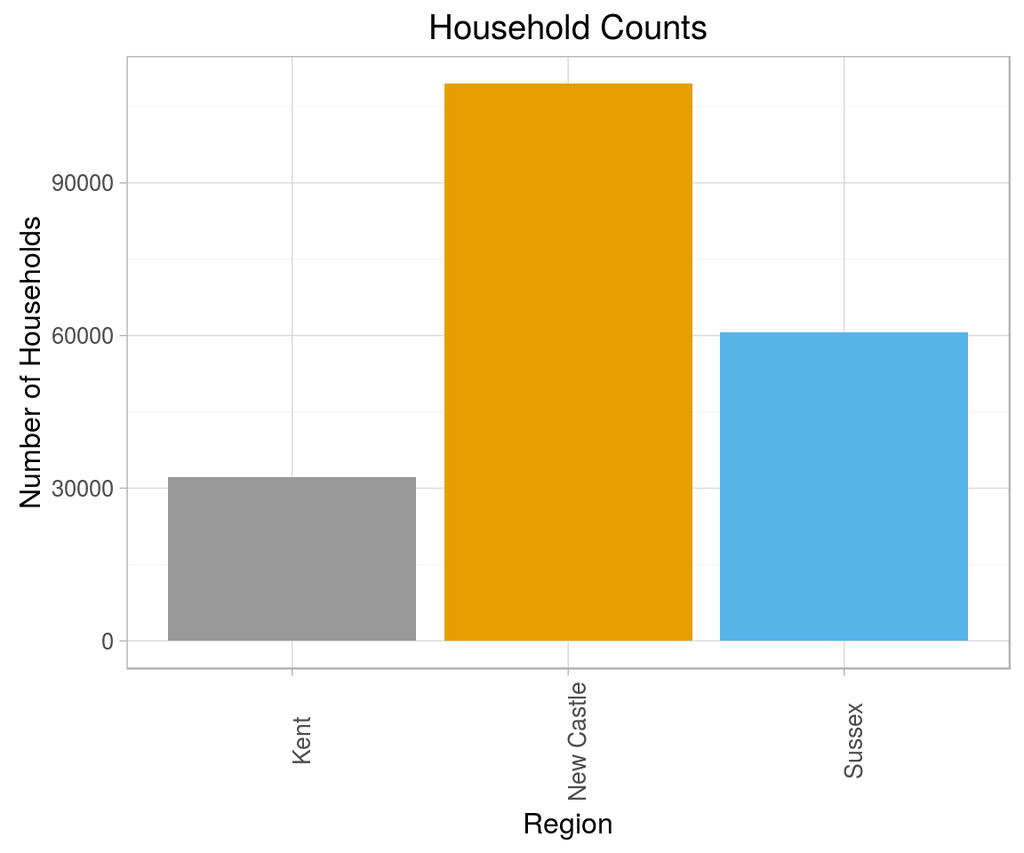

### Household Size

Below is a bar chart of the household size per region.

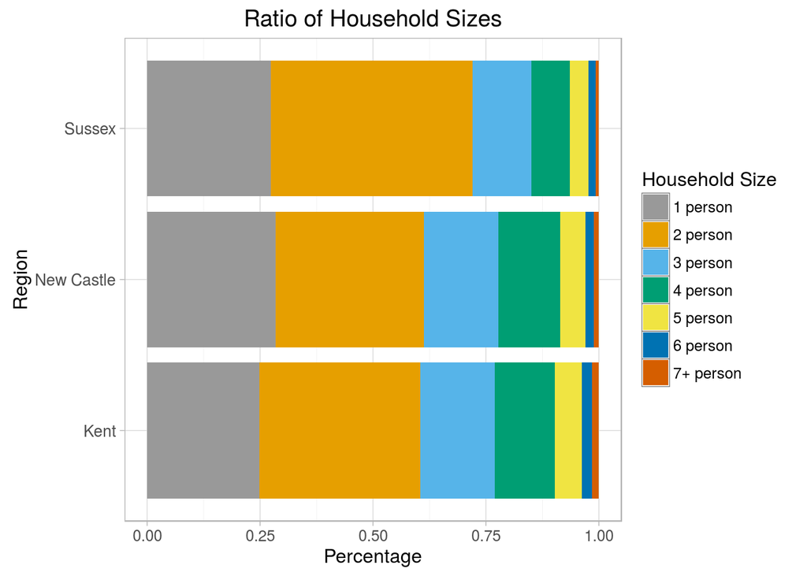

### Household Income

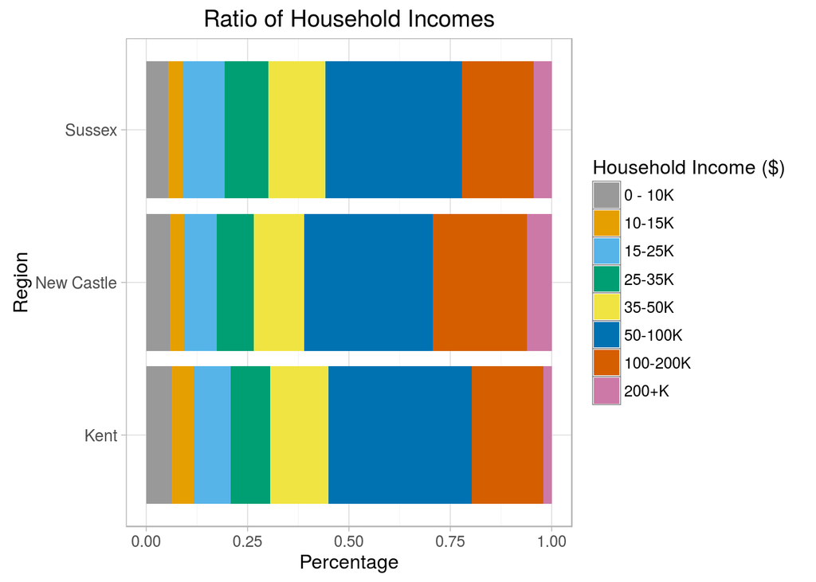

### Column Names

There are 15 columns in the synthetic household ecosystem. They are:

```
##  [1] "RT"        "TYPE"      "SERIALNO"  "puma"      "id"
##  [6] "REGION"    "ST"        "HINCP"     "NP"        "SYNTHETIC"
## [11] "HID"       "place"     "id"        "longitude" "latitude"
```

## Synthetic Persons

**Total Synthetic Persons:** 487,930

### Number of People

Below is a bar chart of the number of people per region.

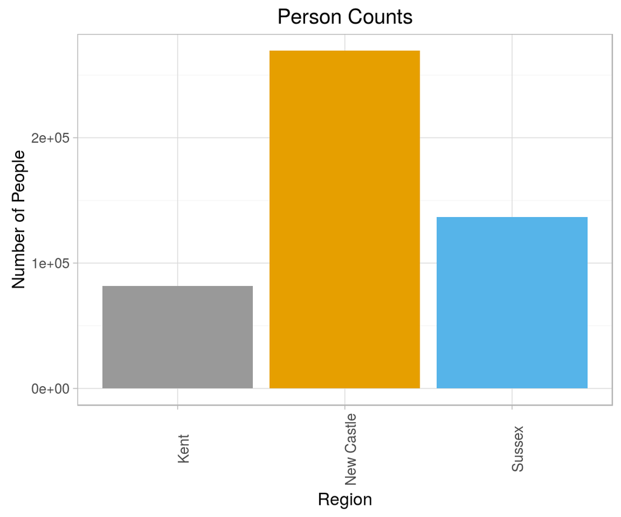

### Male to Female Ratio

Below is a bar chart of male to female ratio

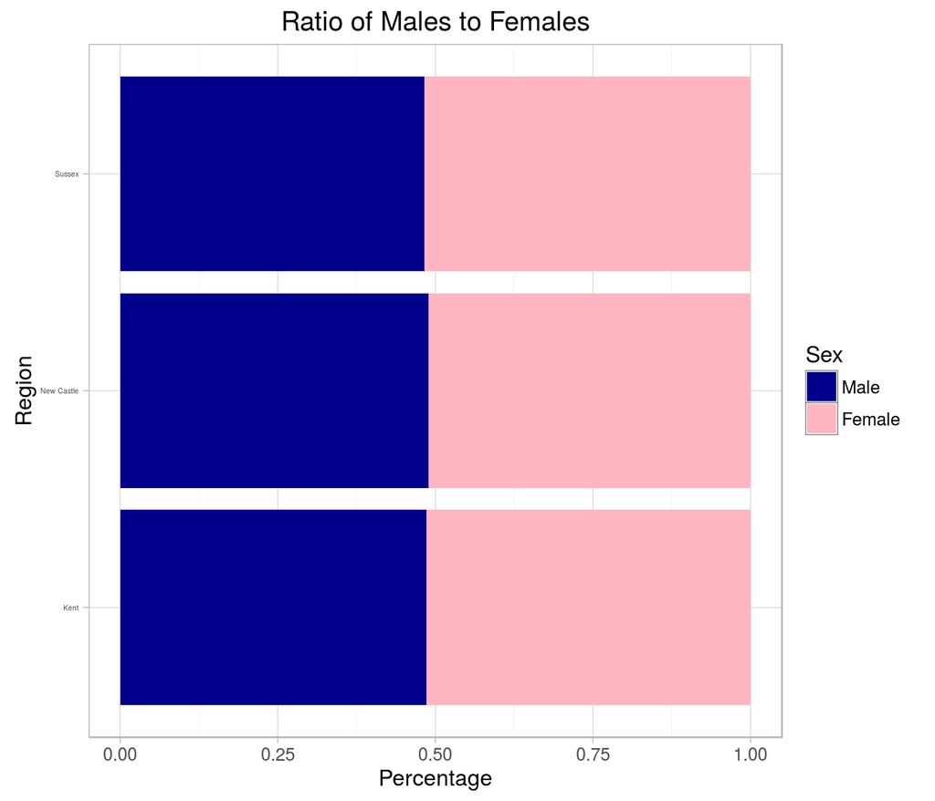

### Age

Below is a bar chart of age ratios per region

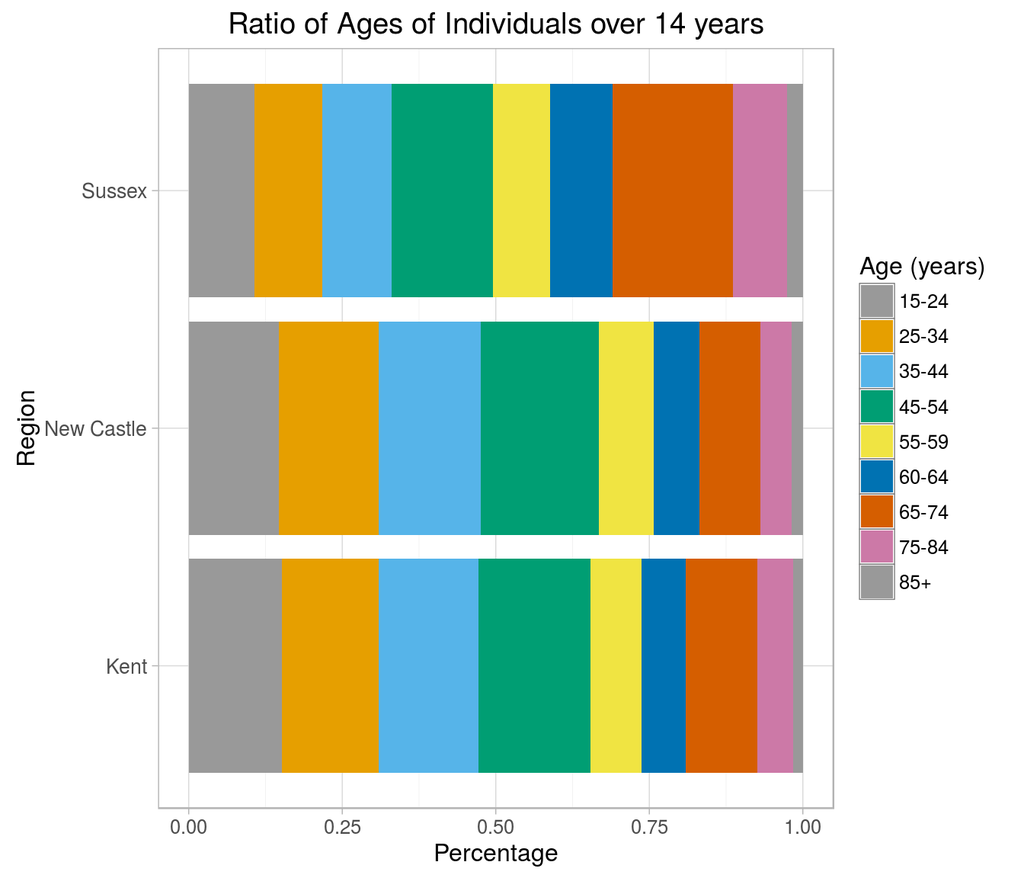

### Race

Below is a bar chart of race ratios per region

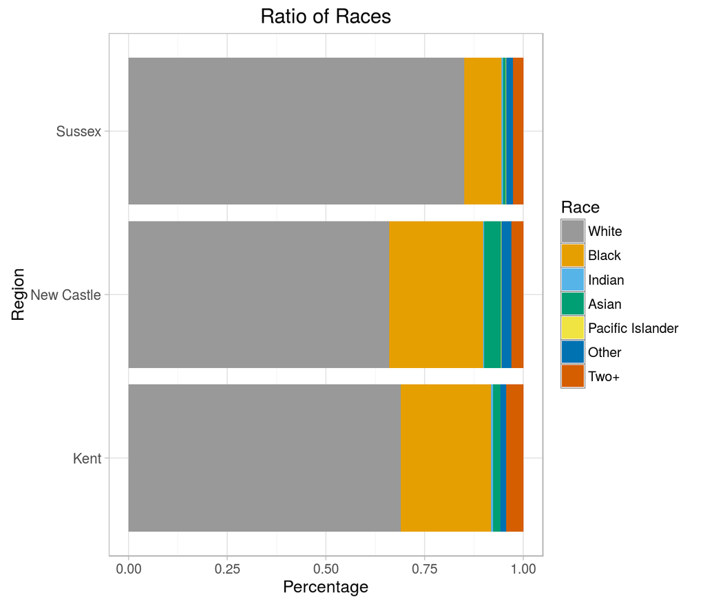

### Column Names

```
##  [1] "RT"        "TYPE"      "SERIALNO"  "puma"      "id"
##  [6] "REGION"    "ST"        "HINCP"     "NP"        "SYNTHETIC"
## [11] "HID"       "place"     "id"        "longitude" "latitude"
## [16] "RT"        "puma"      "id"        "ST"        "SEX"
## [21] "AGEP"      "SCH"       "SCHG"      "RELP"      "HISP"
## [26] "ESR"       "PINCP"     "NATIVITY"  "OCCP"      "POBP"
## [31] "RAC1P"     "SYNTHETIC" "PID"       "school"    "id"
## [36] "workplace" "id"
```

## Generation Information

This report was generated on 2016-09-30 10:36:08 by `spew`, an `R` package used to generate populations throughout the world. Please see our [spew Github repo](https://github.com/leerichardson/spew) and our previously generated regions at [epimodels.org](http://www.epimodels.org/drupal/?q=node/32). We are a part of the Infomatics Services Group MIDAS branch at Carnegie Mellon University and University of Pittsburgh and are supported by 1 U24 GM110707-01 NIH/NIGMS grant. Please send your comments and suggestions to sventura@stat.cmu.edu.